```python
import pandas as pd
import glob
import cv2
import os
import csv
import seaborn as sn
import PIL
import numpy as np
import matplotlib.pyplot as plt
import itertools as it
import xgboost as xgb
import time
from matplotlib.image import imread
from PIL import Image
from sklearn.decomposition import PCA
from sklearn.neighbors import KNeighborsClassifier
from sklearn.preprocessing import StandardScaler
from sklearn import metrics
from sklearn.model_selection import train_test_split
from sklearn.model_selection import cross_val_score
from sklearn.model_selection import RandomizedSearchCV, GridSearchCV
from sklearn.metrics import confusion_matrix
from sklearn.metrics import plot_confusion_matrix
from sklearn.svm import SVC
from sklearn.utils.fixes import loguniform
from sklearn.metrics import classification_report
from sklearn.metrics import accuracy_score
from sklearn.model_selection import cross_val_score
from sklearn.model_selection import KFold
from sklearn.cluster import KMeans
```

This work is about face recognition using unsupervised learning method to reduce dimensionality of the data and then apply other models to classify data to a unique Id that each person has.

# About Data

The data was taken from [Kaggle Website](https://www.kaggle.com/code/lalitharajesh/face-recognition-eigenfaces/data), where the images are already pixelized and in grayscale. It is not necessary, but makes the work easier and faster.

Data consists in 400 face images of 64 x 64 pixels. Each person has 10 different photos. The images are already in the same size, so they do not need to be chopped or scaled. All backgrounds are black. To get accuracy, I asked for the data owner to upload the labels data frame.

```python
faces_image = np.load('olivetti_faces.npy')
labelss = np.load('olivetti_faces_target.npy')

images_path = glob.glob('myphotos/*.jpg')
images_path2 = glob.glob('bw-pic/*.jpg')
```

```
(64, 64)
```

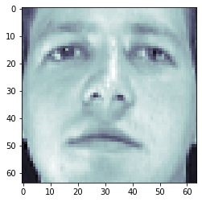

```python
plt.imshow(faces_image[6], cmap='bone')
faces_image[1].shape
```

After a first look at the images, the next step is to make images flatten and put them all in a data frame, where each column is a pixel and each row is an image. Get_image method does that and makes the train-test split and defines data.X and target data.Y.

```python
class get_image:
    def __init__(self, dsize_x, dsize_y):
        dsize = (dsize_x, dsize_y)

        labels=[]
        pix_img=list()
        for image in faces_image:
            image1 = image.flatten()
            pix_img.append(image1)


        self.size = (len(pix_img), dsize_x, dsize_y )
        img_names = os.listdir('bw-pic')

        uniqueWord = [];
        num_lab=[]
        for elt in labels:
            if elt not in uniqueWord:
                uniqueWord.append(elt);

        for word in labels:
            num_lab.append(uniqueWord.index(word) + 1)


        df = pd.DataFrame(num_lab, columns = ['labels'])
        df['labels'] = labelss
        self.y= df['labels']
        self.X=pd.DataFrame(pix_img)
        self.X_train, self.X_test, self.y_train, self.y_test = train_test_split(self.X, self.y, test_size=0.2, random_state=42)


def show_img(data, unique_ids):
    fig, ax_arr = plt.subplots( 5 , 8, figsize = (20,10))
    ax_arr=ax_arr.flatten()
    for unique_id in unique_ids:
        idx = unique_id*10
        ax_arr[unique_id].imshow(data[idx], cmap = 'bone')
        ax_arr[unique_id].set_xticks([])
        ax_arr[unique_id].set_yticks([])
    plt.suptitle("Each distinct people in the dataset")
```

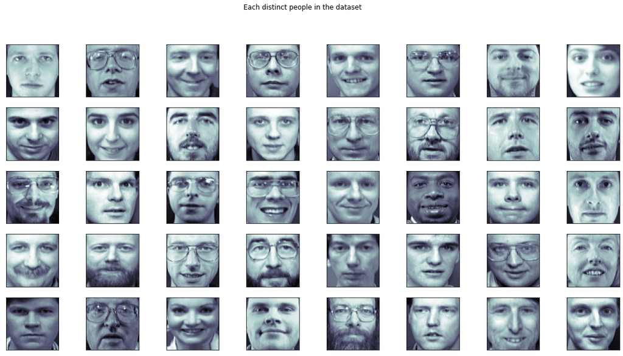

```python
show_img(faces_image, np.unique(labelss))
```

# EDA

Previous chapter consists in data loading and what are the images characteristics. To sumarize it, the dataframe has shape 400x4096, where each line is an flatten image with shape 64x64.

```python
data = get_image(64,64)

print('Data shape is:', data.X.shape)
data.X.head()
```

```
Data shape is: (400, 4096)
```

|  | 0 | 1 | 2 | 3 | 4 | 5 | 6 | 7 | 8 | 9 | ... | 4086 | 4087 | 4088 | 4089 | 4090 | 4091 | 4092 | 4093 | 4094 | 4095 |
| --- | --- | --- | --- | --- | --- | --- | --- | --- | --- | --- | --- | --- | --- | --- | --- | --- | --- | --- | --- | --- | --- |
| 0 | 0.309917 | 0.367769 | 0.417355 | 0.442149 | 0.528926 | 0.607438 | 0.657025 | 0.677686 | 0.690083 | 0.685950 | ... | 0.665289 | 0.669421 | 0.652893 | 0.661157 | 0.475207 | 0.132231 | 0.148760 | 0.152893 | 0.161157 | 0.157025 |
| 1 | 0.454545 | 0.471074 | 0.512397 | 0.557851 | 0.595041 | 0.640496 | 0.681818 | 0.702479 | 0.710744 | 0.702479 | ... | 0.136364 | 0.157025 | 0.136364 | 0.148760 | 0.152893 | 0.152893 | 0.152893 | 0.152893 | 0.152893 | 0.152893 |
| 2 | 0.318182 | 0.400826 | 0.491736 | 0.528926 | 0.586777 | 0.657025 | 0.681818 | 0.685950 | 0.702479 | 0.698347 | ... | 0.074380 | 0.132231 | 0.181818 | 0.136364 | 0.128099 | 0.148760 | 0.144628 | 0.140496 | 0.148760 | 0.152893 |
| 3 | 0.198347 | 0.194215 | 0.194215 | 0.194215 | 0.190083 | 0.190083 | 0.243802 | 0.404959 | 0.483471 | 0.516529 | ... | 0.652893 | 0.636364 | 0.657025 | 0.685950 | 0.727273 | 0.743802 | 0.764463 | 0.752066 | 0.752066 | 0.739669 |
| 4 | 0.500000 | 0.545455 | 0.582645 | 0.623967 | 0.648760 | 0.690083 | 0.694215 | 0.714876 | 0.723140 | 0.731405 | ... | 0.190083 | 0.161157 | 0.177686 | 0.173554 | 0.177686 | 0.177686 | 0.177686 | 0.177686 | 0.173554 | 0.173554 |

5 rows × 4096 columns

Even if the data provider have told us that there is 10 images from each person, it is important to check it. The pros of checking it is to reduce bias in training models and to check data integrity. In this case, all images have the same dimensions, otherwise we would have to scale it in order to do comparisions.

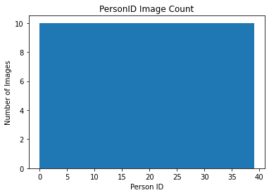

```python
plt.hist(data.y, bins=40, rwidth=1) ;
plt.ylabel('Number of Images');
plt.xlabel('Person ID');
plt.title("PersonID Image Count");
```

A good overview of the data is plotting the mean face of the entire data. A reshape back to 64x64 is necessary to print it.

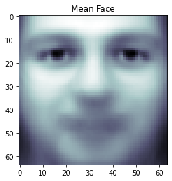

```python
mean_face = np.mean(data.X, axis = 0).to_numpy().reshape(64,64)
plt.imshow(mean_face,  cmap='bone');
plt.title("Mean Face");
```

## Dimensionality Reduction using PCA

First of all, we need to standardize data. In other words, extract the mean and divide it by its standard deviation. In practical meaning, we remove the mean face from each one of the images. N_components parameter must be set accordingly to the total explained variance and model execution time. Image recognition can be a lot slower when dealing with videos, as it must be fast and continuous. Other case that can requires greater speeds are when dealing with a large image database. So it usually happens that very sophisticated models works with less speed than necessary.

```python
scaler = StandardScaler()
X_train = scaler.fit_transform(data.X)
X_test = scaler.transform(data.X)
print(X_train[0])
X_train.shape
```

```
[-0.49990333 -0.35118144 -0.30296149 ... -0.89827548 -0.83151962
 -0.85045689]
```

```
(400, 4096)
```

```python
pca = PCA(n_components=40, random_state=42)
X_train_pca = pca.fit_transform(X_train)
X_test_pca = pca.transform(X_test)
```

```python
print('TOTAL EXPLAINED VARIANCE FOR N_COMPONENTS =', pca.n_components, 'IS', pca.explained_variance_ratio_.sum())
print('SINGULAR VALUES FOR N_COMPONENTS =', pca.n_components, 'IS', pca.singular_values_)
```

```
TOTAL EXPLAINED VARIANCE FOR N_COMPONENTS = 40 IS 0.8507763313664582
SINGULAR VALUES FOR N_COMPONENTS = 40 IS [663.5840038  449.68599692 358.43212745 277.16041183 230.62086368
 225.39544636 197.62775902 184.23651296 174.46838353 164.22993209
 158.54190072 148.9255349  142.16434793 136.90139056 133.90362215
 125.29529116 119.18121826 114.01392509 111.536829   108.55227106
 105.06422157 103.25886713  98.66379779  95.24561468  93.80909224
  91.67753735  90.17508668  87.99823312  83.032785    82.09323124
  80.32242983  77.81683368  77.23793216  73.92206851  73.2685441
  72.14313609  70.92461924  68.27227508  67.65044248  65.85460133]
```

After applying Principal Component Analysis, the model decomposed the data in some faces, wich are called eigenfaces. Each one of peoples image can be reconstructed by adding each weighted eigenface.

```python
eigenfaces = pca.components_
eigenfaces.shape
```

```
(40, 4096)
```

All eigen faces or n_components.

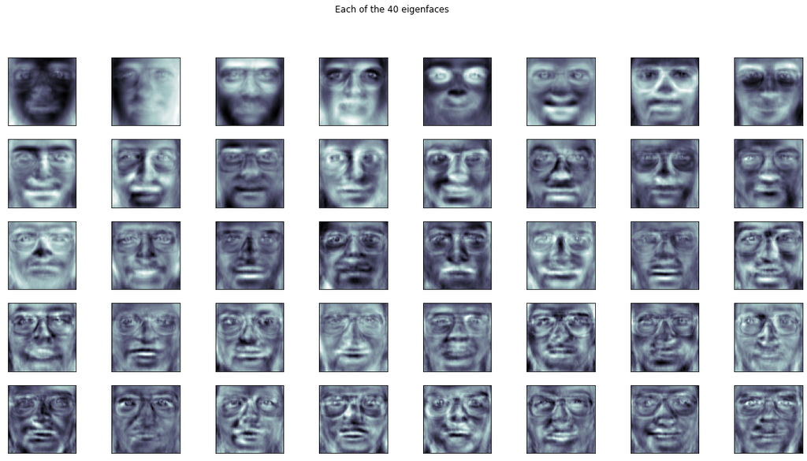

```python
fig, ax_arr = plt.subplots( 5 , 8, figsize = (20,10))
ax_arr = ax_arr.flatten()
for i in range(eigenfaces.shape[0]):
    ax_arr[i].imshow(eigenfaces[i].reshape(64,64), cmap = 'bone')
    ax_arr[i].set_xticks([])
    ax_arr[i].set_yticks([])
    plt.suptitle("Each of the 40 eigenfaces")
```

PCA transformed data can be used with many classification models. The models that will be used in this work are KNN, SVM, KMeans++ and XGBoost Classfier. All methods are going to pass by a hyperparameter tunning, looking for the best parameters to fit the models. After modeling data, there will be comparition between them, where not only accuracy will be measured, but the fitting time and score time will be taken into the account too.

# Models

PCA transformed data can be used with many classification models. The models that will be used in this work are KNN, SVM, KMeans++ and XGBoost Classfier. All methods are going to pass by a hyperparameter tunning, looking for the best parameters to fit the models. After all models construction there will be comparition between them, where not only accuracy will be measured, but the fitting time and score time will be taken into the account too.

### KNN

Looking at the theoretical foundations, Knn seems to be an good model. The faces can be angled in the images, but the data set is well framed and with monocolor background, making possible to evaluate the faces only by distance.

```python
param_grid = {"n_neighbors":  range(4, 10),}

knn_mod = GridSearchCV(KNeighborsClassifier(), param_grid)
knn_mod = knn_mod.fit(X_train_pca, data.y)

print(knn_mod.best_estimator_)
df_knn = pd.DataFrame(knn_mod.cv_results_)

df_knn['name'] = 'KNN'
df_knn.insert(0, 'Model Name', df_knn['name'])
knn_final = df_knn[df_knn.rank_test_score == 1].head(1)
knn_final
```

```
KNeighborsClassifier(n_neighbors=4)
```

|  | Model Name | mean_fit_time | std_fit_time | mean_score_time | std_score_time | param_n_neighbors | params | split0_test_score | split1_test_score | split2_test_score | split3_test_score | split4_test_score | mean_test_score | std_test_score | rank_test_score | name |
| --- | --- | --- | --- | --- | --- | --- | --- | --- | --- | --- | --- | --- | --- | --- | --- | --- |
| 0 | KNN | 0.0004 | 0.00049 | 0.002 | 0.000633 | 4 | {'n_neighbors': 4} | 0.8625 | 0.9 | 0.8625 | 0.9125 | 0.825 | 0.8725 | 0.031024 | 1 | KNN |

### Kmeans

Although Kmeans clustering uses distance to classify the data, it does not compare exactly pixels but cluster distances. This could lead to missclassification. So it is not expected to get as high as other models metric scores.

```python
param_grid = {"init":  ['k-means++', 'random'],
              "algorithm" : [ 'elkan', 'auto', 'full']}

kmeans_mod = KMeans(init = 'k-means++', n_clusters = 40)
start = time.time()
kmeans_mod = kmeans_mod.fit(X_train_pca)
end = time.time()
print(kmeans_mod.labels_)

start1 = time.time()
acc = metrics.adjusted_rand_score(data.y, kmeans_mod.labels_)
end1 = time.time()

fit_time = end - start
score_time = end1 - start1
df_kmeans = pd.DataFrame([(1,2,3,4)],  columns=['Model Name' ,'mean_test_score', 'mean_fit_time', 'mean_score_time'])
df_kmeans['mean_test_score'] = acc
df_kmeans['mean_fit_time'] = fit_time
df_kmeans['mean_score_time'] = score_time
df_kmeans['Model Name'] = 'Kmeans'
df_kmeans
```

```
[27  1 27  5 33  5 27 27 27 33 13 13 13 13 13 13 13 13 13 13 25 25  8 15
 15 17 17 17 33 33 34 34 34 18 18 17 18 34 13  1  3  3  3  3 32 32 34 32
 32 17 18 18 18  2  2  2  2  2  2  2 29 29 39 29 29 39 29 29 39 29 26 26
 26 24 26 26  1 26 17  1 28 25 28 37 37 37 37 37 37 25  8 24 24 24 33 33
 33 33 32 26 20 20 20 20 20 20 20 20 20 20 33 28 28 28 28 17 28 33 33 33
 34  8 10 10 34  1 15 15 34 34 22 22 22 22 22 22 22 22 22 22 30 34 30 30
 34 30 34 30 34 34  6 27 27 18 18  6 27 27 27 27 32 32 19 19 32  5  5 32
  5  5 18 18 18 18 18 18 18 18 18 18 36 36 36 16 16 36 16 16 16 36  4  4
  4 34 17 34 17 17 17  4  4  4  4 25 25 25 15 15 25 15  9  9  9  9  9  9
  9  9  9  9 18 18  3 37  3 37 37 18 10 17  6  6 38 38  8  6  6  6 38 38
  3  8  3  8  3  8  3 37  3  3 19 19 19 19 19 19 18 19 19  8 11 11 11 11
 11 11 11 11 11 11  8 19 10 20 19  8 19  8 19 10 21 21 21 15 15 15 15 15
 21 21 25  4 25  4  4 25  4  4 25 25  0 35 35 35 35  0  0  0  0 35 16 16
 16 16 16 16 30 16 16 16 14 14 14 14 14 14 14 14 14 14  7  7  7  7  7  7
  7  7  7  7 31 31 15 31 32 31 31 31 32 32 29  6  6  6 29  6  6  6  6  6
 12 23 12 23 23 23 12 23 12 12 17  3  3 33  3  3  3  3 17  3 21 21 21 21
 21 21 21 21 21 21 25 17 17 37 17 25 17 25 32 37]
```

|  | Model Name | mean_test_score | mean_fit_time | mean_score_time |
| --- | --- | --- | --- | --- |
| 0 | Kmeans | 0.446586 | 0.09202 | 0.001 |

### SVC

SVC works by mapping data points to a high-dimensional space and then finding the optimal hyperplane that divides the data into two classes.

```python
param_grid = {
    "C": loguniform(1e1, 1e5),
    "gamma": loguniform(1e-4, 1e1),
    'kernel':["rbf", "linear", 'poly', 'sigmoid']
}


clf_svm = RandomizedSearchCV(
    SVC( class_weight="balanced"), param_grid, n_iter=20
)
clf_svm = clf_svm.fit(X_train_pca, data.y)
print(clf_svm.best_estimator_)

df_svm = pd.DataFrame(clf_svm.cv_results_)
df_svm['name'] = 'SVC'
df_svm.insert(0, 'Model Name', df_svm['name'])
svm_final = df_svm[df_svm.rank_test_score == 1].head(1)
svm_final
```

```
SVC(C=16324.663013968915, class_weight='balanced', gamma=0.04812991955653672,
    kernel='linear')
```

|  | Model Name | mean_fit_time | std_fit_time | mean_score_time | std_score_time | param_C | param_gamma | param_kernel | params | split0_test_score | split1_test_score | split2_test_score | split3_test_score | split4_test_score | mean_test_score | std_test_score | rank_test_score | name |
| --- | --- | --- | --- | --- | --- | --- | --- | --- | --- | --- | --- | --- | --- | --- | --- | --- | --- | --- |
| 2 | SVC | 0.008002 | 4.623108e-07 | 0.0016 | 0.00049 | 16324.7 | 0.0481299 | linear | {'C': 16324.663013968915, 'gamma': 0.048129919... | 1.0 | 0.9625 | 0.9875 | 0.9625 | 0.95 | 0.9725 | 0.018371 | 1 | SVC |

```python
scores = cross_val_score(clf_svm.best_estimator_, X_train_pca, data.y , cv = KFold(n_splits=10, shuffle=True))
scores.mean()
```

```
0.9675
```

```
0.9875
              precision    recall  f1-score   support

           0       1.00      1.00      1.00         3
           1       1.00      1.00      1.00         1
           2       1.00      1.00      1.00         2
           3       1.00      1.00      1.00         4
           4       1.00      1.00      1.00         3
           5       1.00      1.00      1.00         3
           7       1.00      0.83      0.91         6
           8       1.00      1.00      1.00         2
           9       1.00      1.00      1.00         2
          10       1.00      1.00      1.00         2
          11       1.00      1.00      1.00         3
          12       1.00      1.00      1.00         2
```

[output cut: 28 more lines]

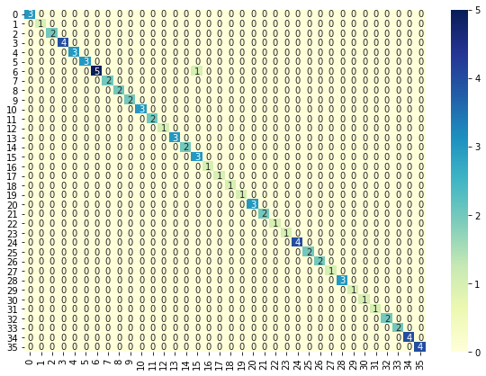

```python
scaler = StandardScaler()
X_train = scaler.fit_transform(data.X_train)
X_test = scaler.transform(data.X_test)

pca = PCA(n_components=40)
X_train_pca = pca.fit_transform(X_train)
X_test_pca = pca.transform(X_test)

clf = clf_svm.best_estimator_.fit(X_train_pca, data.y_train)

y_pred = clf.predict(X_test_pca)
print(accuracy_score(data.y_test, y_pred))

cm = confusion_matrix(data.y_test, y_pred)


df_cm = pd.DataFrame(cm, index = [i for i in range(cm.shape[0])],
                  columns = [i for i in range(cm.shape[1])])

plt.figure(figsize = (10,7))
sn.heatmap(df_cm, annot=True, cmap="YlGnBu")

print(classification_report(data.y_test, y_pred))
```

### XGBoost

```python
scaler = StandardScaler()
X_train = scaler.fit_transform(data.X)
pca = PCA(n_components=40, random_state=42)
X_train_pca = pca.fit_transform(X_train)

param_grid = {
    "max_depth": [3,4,5],
    "learning_rate": [0.1, 0.01, 0.05],
    'gamma':[0, 0.1],
    'reg_lambda': [ 1.0, 10],
}

param_grid = {
    "max_depth": [3],
    "learning_rate": [0.1, 0.2, 0.5],
    'gamma':[0, 0.1],
    'reg_lambda': [ 1.0, 2, 3],
}

param_grid = {
    "max_depth": [3],
    "learning_rate": [0.5, 0.6, 0.75],
    'gamma':[0],
    'reg_lambda': [0, 1.0, ],
}


clf_xgb =  GridSearchCV(
    xgb.XGBClassifier(objective="multi:softprob", random_state=43), param_grid)



clf_xgb = clf_xgb.fit(X_train_pca, data.y)
print(clf_xgb.best_estimator_)
```

```
XGBClassifier(base_score=0.5, booster='gbtree', callbacks=None,
              colsample_bylevel=1, colsample_bynode=1, colsample_bytree=1,
              early_stopping_rounds=None, enable_categorical=False,
              eval_metric=None, gamma=0, gpu_id=-1, grow_policy='depthwise',
              importance_type=None, interaction_constraints='',
              learning_rate=0.5, max_bin=256, max_cat_to_onehot=4,
              max_delta_step=0, max_depth=3, max_leaves=0, min_child_weight=1,
              missing=nan, monotone_constraints='()', n_estimators=100,
              n_jobs=0, num_parallel_tree=1, objective='multi:softprob',
              predictor='auto', random_state=43, reg_alpha=0, ...)
```

```python
print(clf_xgb.best_estimator_.reg_lambda)
```

```
1.0
```

```
[[3 0 0 ... 0 0 0]
 [0 1 0 ... 0 0 0]
 [0 0 2 ... 0 0 0]
 ...
 [0 0 0 ... 2 0 0]
 [0 0 0 ... 0 4 0]
 [0 0 0 ... 0 0 4]]
              precision    recall  f1-score   support

           0       1.00      1.00      1.00         3
           1       1.00      1.00      1.00         1
           2       1.00      1.00      1.00         2
           3       1.00      1.00      1.00         4
           4       1.00      1.00      1.00         3
           5       1.00      1.00      1.00         3
```

[output cut: 34 more lines]

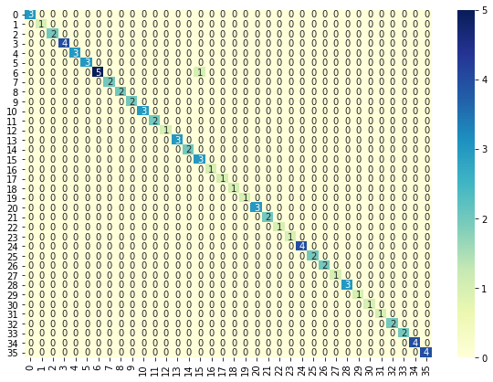

```python
scaler = StandardScaler()
X_train = scaler.fit_transform(data.X_train)
X_test = scaler.transform(data.X_test)

pca = PCA(n_components=40)
X_train_pca = pca.fit_transform(X_train)
X_test_pca = pca.transform(X_test)

xgb_model = xgb.XGBClassifier(objective="multi:softprob", max_depth=3, learning_rate=0.1, gamma=0, random_state=43)
xgb_model = clf_svm.best_estimator_
start = time.time()
xgb_model.fit(X_train_pca, data.y_train)
end = time.time()
y_pred = xgb_model.predict(X_test_pca)

fit_time = end - start
print(confusion_matrix(data.y_test, y_pred))

cm = confusion_matrix(data.y_test, y_pred)
df_cm = pd.DataFrame(cm, index = [i for i in range(confusion_matrix(data.y_test, y_pred).shape[0])],
                  columns = [i for i in range(confusion_matrix(data.y_test, y_pred).shape[0])])

plt.figure(figsize = (10,7))
sn.heatmap(df_cm, annot=True, cmap="YlGnBu")

print(classification_report(data.y_test, y_pred));
```

```python
scaler = StandardScaler()
X_train = scaler.fit_transform(data.X)
X_test = scaler.transform(data.X)

pca = PCA(n_components=35)
X_train_pca = pca.fit_transform(X_train)
X_test_pca = pca.transform(X_test)


xgb_model = clf_xgb.best_estimator_
start1 = time.time()
scores = cross_val_score(xgb_model, X_train_pca, data.y, scoring="accuracy", cv=5)
end1 = time.time()
score_time = end1 - start1
print('CROSS VALIDATION MEAN ACCURACY:', scores.mean())
```

[output not shown]

```python
df_xgboost = pd.DataFrame([(1,2,3,4)],  columns=['Model Name' ,'mean_test_score', 'mean_fit_time', 'mean_score_time'])
df_xgboost['mean_test_score'] = scores.mean()
df_xgboost['mean_score_time'] = score_time
df_xgboost['Model Name'] = 'XGBoost'
df_kmeans['mean_fit_time'] = fit_time
df_xgboost
```

[output not shown]

# Conclusion

```python
frames = [knn_final, svm_final, df_xgboost, df_kmeans]

result = pd.concat(frames)

result = result.drop(['std_fit_time',
                      'std_score_time',
                      'param_n_neighbors',
                      'params',
                      'split0_test_score',
                      'split1_test_score',
                      'split2_test_score',
                      'split3_test_score',
                      'split4_test_score',
                      'rank_test_score',
                      'name', 'param_C',
                      'param_gamma',
                      'param_kernel'], axis=1)

display(result)
```

[output not shown]

# Extra

I took the olivetti dataset and added 10 different photos of me to see how SVC performs. The photos are tottaly different from the original data, and no black background could lead to high miss classification. By the way it is a good experiment to see how it will work.

```python
class get_image_from_folder:
    def __init__(self, dsize_x, dsize_y):
        dsize = (dsize_x, dsize_y)
        i=0
        labels=[]
        pix_img=list()
        for image in images_path:
            img = cv2.imread(image)
            folder=os.path.split(os.path.dirname(image))[-1]
            gray_img = cv2.cvtColor(img, cv2.COLOR_BGR2GRAY)
            gray_img = cv2.resize(gray_img, dsize)
            gray_img_pix = gray_img.flatten()
            pix_img.append(gray_img_pix)
            cv2.imwrite('bw-pic/image%02i.jpg' %i, gray_img)
            labels.append(folder)
            i=i+1

        img_names = os.listdir('bw-pic')

        uniqueWord = [];
        num_lab=[]
        for elt in labels:
            if elt not in uniqueWord:
                uniqueWord.append(elt);

        for word in labels:
            num_lab.append(uniqueWord.index(word) + 1)


        df = pd.DataFrame(num_lab, columns = ['labels'])
        self.y= df['labels']
        self.X=pd.DataFrame(pix_img)

        self.X_train, self.X_test, self.y_train, self.y_test = train_test_split(self.X, self.y, test_size=0.2, random_state=42)
```

```python
data = get_image(64,64)

print('Data shape is:', data.X.shape)
data.X.head()
```

```python
my_data = get_image_from_folder(64,64)
#my_data.X=(my_data.X-my_data.X.min())/(my_data.X.max()-my_data.X.min())


frames = [ data.X, my_data.X]

result = pd.concat(frames)
data.X = result
display(data.X)
```

```python
fig, ax_arr = plt.subplots( 2 , 5, figsize = (20,10))
ax_arr = ax_arr.flatten()

for i in range(my_data.X.shape[0]):
    ax_arr[i].imshow(my_data.X.to_numpy()[i].reshape(64,64), cmap = 'bone')
    ax_arr[i].set_xticks([])
    ax_arr[i].set_yticks([])
    plt.suptitle("10 different photos from me taken with webcam razer kiyo")
```

[output not shown]

```python
mean_face = np.mean(data.X, axis = 0).to_numpy().reshape(64,64)
plt.imshow(mean_face,  cmap='bone');
plt.title("Mean Face");
```

```python
mylabels = np.array([40,40,40,40,40,40,40,40,40,40])
df1 = pd.DataFrame(mylabels)
frames = [ data.y, df1]



result = pd.concat(frames)
data.y = result[0]
display(data.y)

data.X_train, data.X_test, data.y_train, data.y_test = train_test_split(data.X, data.y, test_size=0.25, random_state=42)
data.y_train
```

```python
scaler = StandardScaler()
X_train = scaler.fit_transform(data.X)
pca = PCA(n_components=40, random_state=42)
X_train_pca = pca.fit_transform(X_train)
```

```python
param_grid = {
    "C": loguniform(1e1, 1e5),
    "gamma": loguniform(1e-4, 1e1),
    'kernel':["rbf", "linear", 'poly', 'sigmoid']
}


clf_svm = RandomizedSearchCV(
    SVC( class_weight="balanced"), param_grid, n_iter=20
)
clf_svm = clf_svm.fit(X_train_pca, data.y)
print(clf_svm.best_estimator_)

df_svm = pd.DataFrame(clf_svm.cv_results_)
df_svm['name'] = 'SVC'
df_svm.insert(0, 'Model Name', df_svm['name'])
svm_final = df_svm[df_svm.rank_test_score == 1].head(1)
svm_final
```

```python
scaler = StandardScaler()
X_train = scaler.fit_transform(data.X_train)
X_test = scaler.transform(data.X_test)

pca = PCA(n_components=40)
X_train_pca = pca.fit_transform(X_train)
X_test_pca = pca.transform(X_test)

clf = clf_svm.best_estimator_.fit(X_train_pca, data.y_train)

y_pred = clf.predict(X_test_pca)
print(accuracy_score(data.y_test, y_pred))

cm = confusion_matrix(data.y_test, y_pred)


df_cm = pd.DataFrame(cm, index = [i for i in range(cm.shape[0])],
                  columns = [i for i in range(cm.shape[1])])

plt.figure(figsize = (10,7))
sn.heatmap(df_cm, annot=True, cmap="YlGnBu")

print(classification_report(data.y_test, y_pred))
```

[output not shown]